# Novel decorating behaviour of silk retreats in a challenging habitat

**Authors:**

Alfonso Aceves-Aparicio*<sup>1, 2</sup>, Donald James McLean<sup>1</sup>, Zoe Korzy Wild<sup>1</sup>, Jutta M. Schneider<sup>2</sup> and Marie E. Herberstein<sup>1</sup>

1, Department of Biological Sciences, Macquarie University, Sydney, NSW, 2109, Australia

2, Institute of Zoology, Universität Hamburg, Hamburg, Germany Corresponding author: Alfonso Aceves-Aparicio Correspondence: bioarach@gmail.com

This is the code used to calculate stats and create the plots included in the manuscript entitled “Novel decorating behaviour of silk retreats in a challenging habitat”.

Document setup: Libraries and Data

```r
library(tidyverse)
library(pavo)
library(printr)
library(DT)
library(kableExtra)
library(plotrix)
library(cowplot)
library(jmv)
library(jmvcore)

source("R/functions.R")
```

## Natural history data

```r
all <- read_csv("Data/surveys.csv")

all <- all %>%
  mutate(across(c(occupied, SurveyName), as_factor))
```

### Summaries: silk retreat and spider size

```r
retreat_summary <- all %>%
  group_by(SurveyName) %>%
  filter(!is.na(BlankieLength)) %>%
  summarise(N_retreat = n_distinct(BlankieID),
            Mean = mean(BlankieLength),
            SEM = std.error(BlankieLength))

retreat_summary %>%
  kableExtra::kbl(align = "r") %>%
  kableExtra::kable_styling(bootstrap_options = "condensed")
```

| SurveyName | N_retreat | Mean | SEM |
| --- | --- | --- | --- |
| 2018-07 | 94 | 12.704110 | 0.4978279 |
| 2018-10 | 78 | 11.123759 | 0.4986312 |
| 2019-01 | 92 | 7.307458 | 0.3198919 |
| 2019-03 | 83 | 9.092711 | 0.3734454 |
| 2019-06 | 125 | 13.154930 | 0.5060880 |
| 2019-10 | 82 | 13.875637 | 0.6169808 |

```r
spider_summary <- all %>%
  group_by(SurveyName) %>%
  filter(!is.na(Prosoma.width)) %>%
  summarise(N_spider = n(),
            Mean = mean(Prosoma.width),
            SEM = std.error(Prosoma.width))

spider_summary %>%
  kableExtra::kbl(align = "r") %>%
  kableExtra::kable_styling(bootstrap_options = "condensed")
```

| SurveyName | N_spider | Mean | SEM |
| --- | --- | --- | --- |
| 2018-07 | 56 | 1.702518 | 0.0377624 |
| 2018-10 | 9 | 1.934444 | 0.0493601 |
| 2019-01 | 6 | 1.053333 | 0.1726589 |
| 2019-03 | 11 | 1.085454 | 0.0409293 |
| 2019-06 | 23 | 1.570870 | 0.0514490 |
| 2019-10 | 10 | 1.795000 | 0.1043099 |

### Plot: Spider size over time

Creating labels for number of spiders per survey

```r
#
n_labels_fig2A <- spider_summary %>% pull(N_spider)
#
all_fig2A <- all %>%
  mutate(new.SurveyName = factor(surveyId, labels = paste0(levels(SurveyName), "\n", "N = ", n_labels_fig2A)))
```

#### Fig 2 A

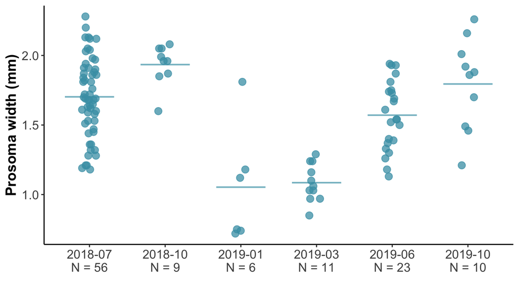

```r
Fig_2A <- all_fig2A %>%
  dplyr::select(new.SurveyName, Prosoma.width) %>%
  ggplot(aes(new.SurveyName, Prosoma.width)) +
  geom_point(aes(group = new.SurveyName),
             position = position_jitter(width = 0.10),
             shape = 19,
             size = 3,
             alpha = 0.75,
             colour = "#469eb4") +
  stat_summary(fun = "mean", fun.min = "mean", fun.max= "mean",
               size= 0.7, colour= "#469eb4", alpha = 0.45,
               geom = "errorbar", width=0.65) +
  ylab("Prosoma width (mm)") +
  xlab("") +
  theme_poncho()

Fig_2A
```

### Plot: Retreat building and occupancy over time

Data preparation for the second plot, here: 1) Grabs the survey number from the BlankieID label (this label is given to the blankie when first recorded) then 2) checks whether it matches the surveyId (this corresponds to the survey date as categorical) to 3) define if the blankie was new or old (pre-existing) in the current survey time. This trait is stored in the variable “newness”

```r
all1 <- all %>%
  mutate(first_record_ID = str_split(BlankieID, "-", simplify = T)[ ,2],
         survey_time_ID = paste0("0", surveyId),
         newness = ifelse(first_record_ID == survey_time_ID, "new", "old")) %>%
  mutate(across(c(newness, occupied, SurveyName), as_factor)) %>%
  mutate(occupied = fct_recode(occupied, Occupied = "TRUE", Vacant = "FALSE"))
```

Adding additional variable where to store the combinations between Occupancy and “Newness”

```r
# Data preparation for figure

all2 <- all1 %>%
  mutate(fourLplot = paste0(newness, "_", occupied)) %>%
  mutate(fourLplot = fct_relevel(fourLplot, "old_Occupied", "old_Vacant", "new_Occupied", "new_Vacant")) %>%
  mutate(newness = fct_relevel(newness, "old", "new"))
```

Defining and storing colours and shapes for figure 2 B

```r
# assigns shapes to each category
shapes_fig2B <- c("old_Occupied" = 19, "old_Vacant" = 1,
                 "new_Occupied" = 19, "new_Vacant" = 1)

# assigns colours to each category
cols_fig2B <- c("old_Occupied" = "#4682b4",
               "old_Vacant" = "#4682b4",
               "new_Occupied" = "#b4464b",
               "new_Vacant" = "#b4464b")
```

Total N labels

```r
total_n_survey <- all2 %>%
  filter(!is.na(BlankieLength)) %>%
  dplyr::select(SurveyName, newness) %>%
  group_by(SurveyName) %>%
  count() %>%
  pull(n)

# add the n label per survey under a line break to each survey name

all2_fig2B <- all2 %>%
  mutate(new.SurveyName = factor(SurveyName, labels = paste0(levels(SurveyName), "\n", "N = ", total_n_survey)))
```

#### Fig 2B

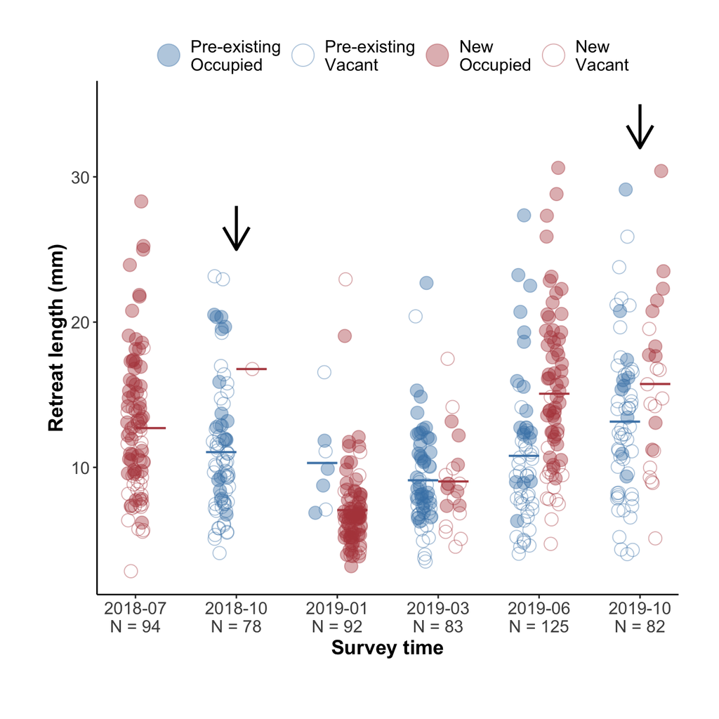

```r
Fig_2B <- ggplot(all2_fig2B) +
  geom_point(size = 4, alpha = 0.4,
             aes(new.SurveyName, BlankieLength,
                 shape = fourLplot,
                 colour = fourLplot,
                 group = newness),
             position = position_jitterdodge(
               jitter.width = 0.50,
               dodge.width = 0.6
             )) +
  guides(color = guide_legend(override.aes = list(size = 7) ) ) +

  stat_summary(aes(new.SurveyName, BlankieLength, group = newness),
               subset(all2_fig2B, newness == "old"),
               fun = "mean", fun.min = "mean", fun.max= "mean",
               size= 0.7, colour= "#4682b4", alpha = 0.80,
               geom = "errorbar", width=0.30,
               position = position_nudge(x = -0.15)) +

    stat_summary(aes(new.SurveyName, BlankieLength, group = newness),
               subset(all2_fig2B, newness == "new"),
               fun = "mean", fun.min = "mean", fun.max= "mean",
               size= 0.7, colour= "#b4464b", alpha = 0.80,
               geom = "errorbar", width=0.30,
               position = position_nudge(x = 0.15)) +

  scale_shape_manual(name="", values=shapes_fig2B,
                     labels = c(paste0("Pre-existing", "\n", "Occupied"),
                                 paste0("Pre-existing", "\n", "Vacant"),
                                 paste0("New", "\n", "Occupied"),
                                 paste0("New", "\n", "Vacant"))) +
  scale_colour_manual(name="",
                      values=cols_fig2B,
                      labels = c(paste0("Pre-existing", "\n", "Occupied"),
                                 paste0("Pre-existing", "\n", "Vacant"),
                                 paste0("New", "\n", "Occupied"),
                                 paste0("New", "\n", "Vacant"))) +
  labs(y = "Retreat length (mm)", x = "Survey time") +
  theme_poncho() +
  theme(plot.caption = element_text(size = 10, hjust = 0)) +
  scale_x_discrete(expand = c(0,0.05))

# adding arrows to indicate presence of adult spiders during survey
Fig_2B <- Fig_2B +
  theme(legend.position = c(0.5, 1.05),
        legend.direction = "horizontal",
        plot.margin=unit(c(2,1,1.5,1.2),"cm")) +
  annotate("segment", x = 6, xend = 6, y = 35, yend = 32,
           colour = "black", size = 1, arrow = arrow()) +
  annotate("segment", x = 2, xend = 2, y = 28, yend = 25,
           colour = "black", size = 1, arrow = arrow())

Fig_2B
```

Summary, number of records in each category in the plot

```r
all2 %>%
  dplyr::select(SurveyName, newness, occupied, BlankieLength) %>%
  mutate(newness = fct_recode(newness,
                              "Pre-existing" = "old",
                              "New" = "new")) %>%
  group_by(SurveyName, newness, occupied) %>%
  count() %>%
  kableExtra::kbl(align = "r") %>%
  kableExtra::kable_styling(c("striped", "hover")) %>%
  scroll_box(width = "100%", height = "400px")
```

| SurveyName | newness | occupied | n |
| --- | --- | --- | --- |
| 2018-07 | New | Vacant | 40 |
| 2018-07 | New | Occupied | 56 |
| 2018-10 | Pre-existing | Vacant | 60 |
| 2018-10 | Pre-existing | Occupied | 19 |
| 2018-10 | New | Vacant | 1 |
| 2019-01 | Pre-existing | Vacant | 3 |
| 2019-01 | Pre-existing | Occupied | 4 |
| 2019-01 | New | Vacant | 20 |
| 2019-01 | New | Occupied | 65 |
| 2019-03 | Pre-existing | Vacant | 28 |
| 2019-03 | Pre-existing | Occupied | 35 |
| 2019-03 | New | Vacant | 12 |
| 2019-03 | New | Occupied | 8 |
| 2019-06 | Pre-existing | Vacant | 37 |
| 2019-06 | Pre-existing | Occupied | 19 |
| 2019-06 | New | Vacant | 18 |
| 2019-06 | New | Occupied | 51 |
| 2019-10 | Pre-existing | Vacant | 49 |
| 2019-10 | Pre-existing | Occupied | 10 |
| 2019-10 | New | Vacant | 13 |
| 2019-10 | New | Occupied | 10 |

#### Composite Fig 2

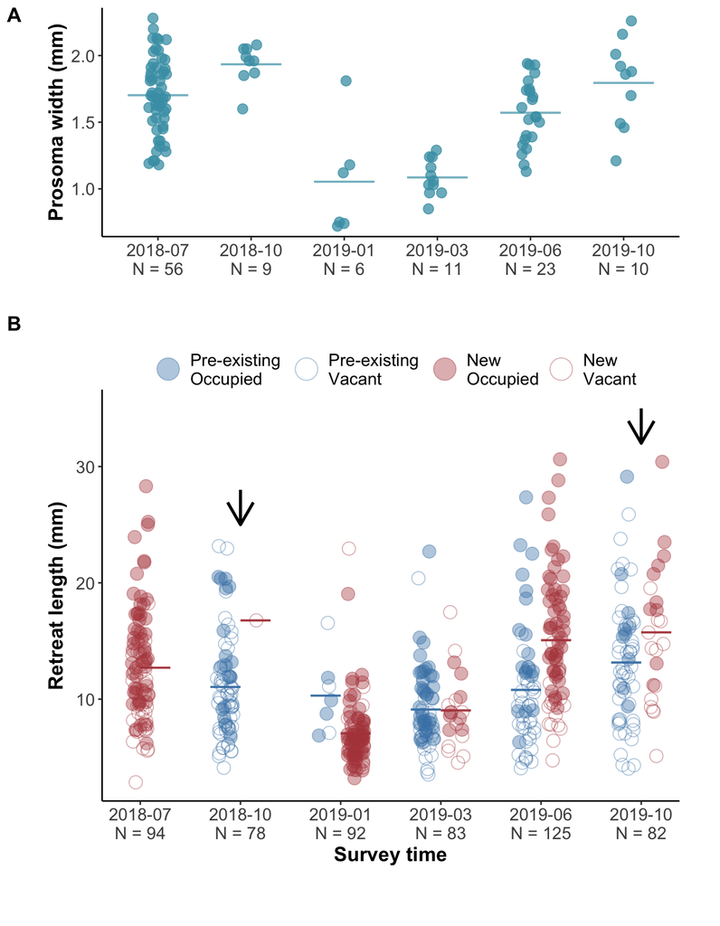

```r
Figure_2 <- plot_grid(Fig_2A, Fig_2B, ncol=1, align="v", labels = "AUTO", rel_heights = c(1, 2))
Figure_2
```

#### 2 Way ANOVA

```r
### 2 Way ANOVA
data <- all %>%
  filter(!is.na(BlankieLength)) %>%
  mutate(log.BlankieLength = log10(BlankieLength))

jmv::ANOVA(
  formula = log.BlankieLength ~ SurveyName + occupied + SurveyName:occupied,
  data = data,
  effectSize = "partEta",
  homo = TRUE,
  norm = TRUE,
  postHoc = ~ SurveyName + occupied + SurveyName:occupied,
  postHocES = "d",
  emMeans = ~ SurveyName:occupied,
  emmPlots = FALSE,
  emmTables = TRUE)
```

```
## NOTE: Results may be misleading due to involvement in interactions
## NOTE: Results may be misleading due to involvement in interactions
```

```
##
##  ANOVA
##
##  ANOVA - log.BlankieLength
##  ───────────────────────────────────────────────────────────────────────────────────────────────────────
##                           Sum of Squares    df     Mean Square    F            p             η²p
##  ───────────────────────────────────────────────────────────────────────────────────────────────────────
##    SurveyName                  4.3114242      5     0.86228484    37.501499    < .0000001    0.2570330
##    occupied                    2.1897697      1     2.18976974    95.234944    < .0000001    0.1494503
##    SurveyName:occupied         0.9671855      5     0.19343711     8.412744     0.0000001    0.0720191
##    Residuals                  12.4623919    542     0.02299334
##  ───────────────────────────────────────────────────────────────────────────────────────────────────────
##
##
##  ASSUMPTION CHECKS
##
##  Homogeneity of Variances Test (Levene's)
##  ────────────────────────────────────────
##    F           df1    df2    p
##  ────────────────────────────────────────
##    1.202956     11    542    0.2816168
##  ────────────────────────────────────────
##
##
##  Normality Test (Shapiro-Wilk)
##  ─────────────────────────────
##    Statistic    p
##  ─────────────────────────────
##    0.9971331    0.4459794
##  ─────────────────────────────
##
##
##  POST HOC TESTS
##
##  Post Hoc Comparisons - SurveyName
##  ──────────────────────────────────────────────────────────────────────────────────────────────────────────────────────────
##    SurveyName         SurveyName    Mean Difference    SE            df          t              p-tukey       Cohen's d
##  ──────────────────────────────────────────────────────────────────────────────────────────────────────────────────────────
##    2018-07       -    2018-10           0.009493781    0.02612530    542.0000      0.3633941     0.9991700    0.015439136
##                  -    2019-01           0.218466932    0.02415359    542.0000      9.0449052    < .0000001    0.384281199
```

[output cut: 103 more lines]

```
##    occupied    SurveyName    Mean         SE            Lower        Upper
##  ───────────────────────────────────────────────────────────────────────────────
##    FALSE       2018-07       0.9719571    0.02397569    0.9248605    1.0190538
##                2018-10       0.9869518    0.01941494    0.9488140    1.0250895
##                2019-01       0.8524353    0.03161820    0.7903261    0.9145445
##                2019-03       0.8675504    0.02397569    0.8204537    0.9146470
##                2019-06       0.9299943    0.02044653    0.8898302    0.9701585
##                2019-10       1.0619435    0.01925774    1.0241146    1.0997725
##    TRUE        2018-07       1.1469334    0.02063499    1.1063990    1.1874677
##                2018-10       1.1129511    0.03677703    1.0407082    1.1851941
##                2019-01       0.8295213    0.01825478    0.7936625    0.8653801
##                2019-03       0.9913098    0.02312421    0.9458857    1.0367338
##                2019-06       1.1953067    0.01812392    1.1597050    1.2309084
##                2019-10       1.2365461    0.03390674    1.1699414    1.3031509
##  ───────────────────────────────────────────────────────────────────────────────
```

```r
rm(data)
```

Data preparation for figure 3

```r
colours <- c("Occupied" = "#b4464b", "Vacant" = "#4682b4")

all4.1 <- all %>%
  mutate(log.B.Area = log10(BlankieArea),
         log.B.length = log10(BlankieLength)) %>%
  mutate(SurveyName = as.factor(SurveyName),
         occupied = as.factor(occupied)) %>%
  group_by(SurveyName, occupied) %>%
  summarise(mean=mean(log.B.length, na.rm = TRUE),
            ci.lwr= norm.interval(log.B.length)[1],
            ci.upr= norm.interval(log.B.length)[2],
            .groups = "rowwise")
```

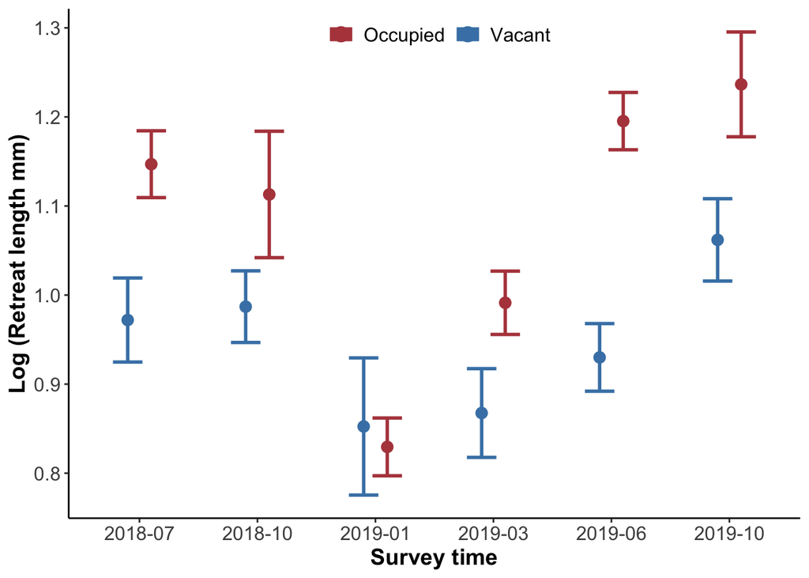

```r
Figure_3 <- ggplot(all4.1, aes(x=SurveyName, y=mean)) +
  geom_point(aes(x=SurveyName, y=mean,
                 color = "Occupied"),
             subset(all4.1, occupied == "TRUE"),
             size = 3,
             position = position_nudge(x = 0.1)) +
  guides(color = guide_legend(override.aes = list(size = 4) ) ) +
  geom_errorbar(aes(x=SurveyName, y=mean,
                    color = "Occupied",
                    ymin=ci.lwr, ymax=ci.upr),
                subset(all4.1, occupied == "TRUE"),
                width=0.25,
                size=1,
                position = position_nudge(x = 0.1)) +
  geom_point(aes(x=SurveyName, y=mean,
                 color = "Vacant"),
             subset(all4.1, occupied == "FALSE"),
             size = 3,
             position = position_nudge(x = -0.1)) +
  geom_errorbar(aes(x=SurveyName, y=mean,
                    color = "Vacant",
                    ymin=ci.lwr, ymax=ci.upr),
                subset(all4.1, occupied == "FALSE"),
                width=0.25,
                size=1,
                position = position_nudge(x = -0.1)) +
  ylab("Log (Retreat length mm)") +
  xlab("Survey time") +
  scale_colour_manual(name=NULL,values=colours) +
  theme_poncho() +
  theme(legend.position=c(0.5, 0.95), legend.direction = "horizontal")

Figure_3
```

```r
# ggsave2(filename = "figure3.pdf", plot = figure_3, device = "pdf", path = "./Output", width = 7, units = "in", dpi = 300)
```

#### 1 Way ANOVA

```
##
##  ONE-WAY ANOVA
##
##  One-Way ANOVA (Welch's)
##  ──────────────────────────────────────────────────────────────────
##                         F           df1    df2         p
##  ──────────────────────────────────────────────────────────────────
##    log.BlankieLength    65.83036      3    55.91568    < .0000001
##  ──────────────────────────────────────────────────────────────────
##
##
##  ASSUMPTION CHECKS
##
##  Normality Test (Shapiro-Wilk)
##  ───────────────────────────────────────────────
##                         W            p
##  ───────────────────────────────────────────────
##    log.BlankieLength    0.9924715    0.4064273
##  ───────────────────────────────────────────────
##    Note. A low p-value suggests a violation
##    of the assumption of normality
##
##
##  Homogeneity of Variances Test (Levene's)
##  ────────────────────────────────────────────────────────────
##                         F           df1    df2    p
##  ────────────────────────────────────────────────────────────
##    log.BlankieLength    1.026444      3    193    0.3820268
##  ────────────────────────────────────────────────────────────
##
##
##  POST HOC TESTS
##
##  Tukey Post-Hoc Test – log.BlankieLength
##  ──────────────────────────────────────────────────────────────────────────────────────
##                                  2019-01      2019-03       2019-06       2019-10
##  ──────────────────────────────────────────────────────────────────────────────────────
##    2019-01    Mean difference            —    -0.1091254    -0.3271582    -0.34402177
##               p-value                    —     0.0266947    < .0000001     < .0000001
##
##    2019-03    Mean difference                          —    -0.2180327    -0.23489636
##               p-value                                  —     0.0000006      0.0000100
##
##    2019-06    Mean difference                                        —    -0.01686361
##               p-value                                                —      0.9694709
##
##    2019-10    Mean difference                                                       —
##               p-value                                                               —
##  ──────────────────────────────────────────────────────────────────────────────────────
##    Note. * p < .05, ** p < .01, *** p < .001
```

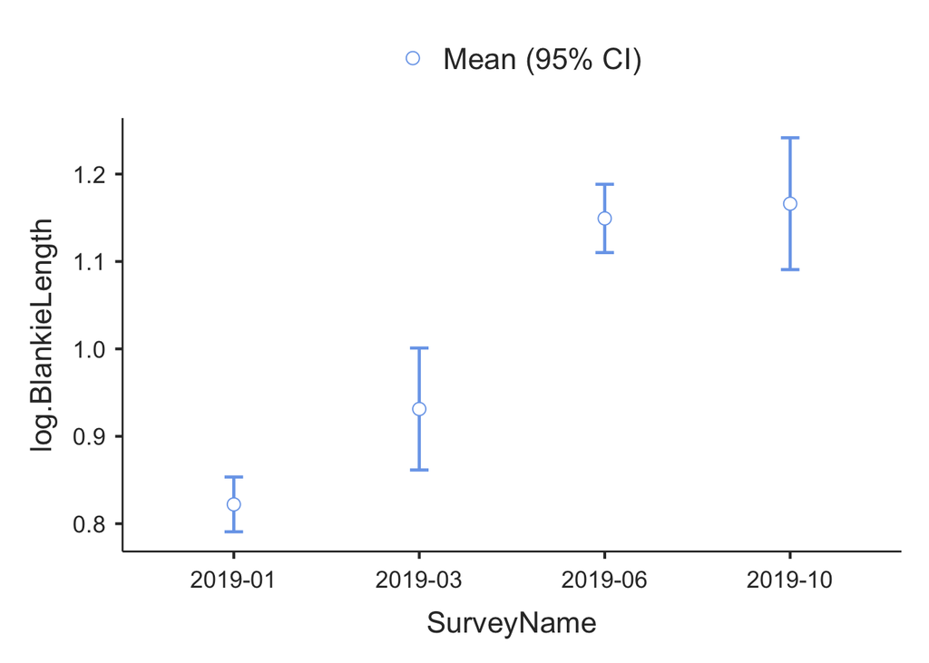

```r
### 1 WAY ANOVA
alljam <-
  all %>%
  mutate(fpID = str_split(BlankieID, "-", simplify = T)[ ,2],
         temporal = paste0("0", surveyId),
         newness = ifelse(fpID == temporal, "new", "old")) %>%
  filter(SurveyName != "2018-07",
         SurveyName != "2018-10") %>%
  filter(newness == "new") %>%
  mutate(log.BlankieLength = log10(BlankieLength)) %>%
  mutate(SurveyName = as.character(SurveyName))


jmv::anovaOneW(
  formula = log.BlankieLength ~ SurveyName,
  data = alljam,
  descPlot = TRUE,
  norm = TRUE,
  eqv = TRUE,
  phMethod = "tukey",
  phFlag = TRUE)
```

```r
rm(alljam)
```

## Reflectance Spectra

Two datasets created here: 1) Clear data - silk retreats collected from concrete water tank, 2) decorated silk, collected from trees.

### Loading data

```r
## "check names = F", stops R from replacing the special characters in the names from the previously exported files

c.specs <-read.csv("Data/clean_specsClear.csv", check.names=FALSE)
c.specs <-as.rspec(c.specs)
```

```
## wavelengths found in column 1
```

```r
d.specs <-read.csv("Data/clean_specsBlankie.csv", check.names=FALSE)
d.specs <-as.rspec(d.specs)
```

```
## wavelengths found in column 1
```

### Averaring, smoothing and plotting samples

First, spectral measurements are averaged per sample (individual decorated or non-decorated blankie).

```r
# Average samples > clear
sample <- sub("\\/.*", "", colnames(c.specs))[-1]
mc.specs <- aggspec(c.specs, by = sample, FUN = "mean")
names(mc.specs)[-1] <- unique(sample)

# Average samples > Decorated Blankie
blankie <- sub("\\/.*", "", colnames(d.specs))[-1]
md.specs <- aggspec(d.specs, by = blankie, FUN = "mean")
names(md.specs)[-1] <- unique(blankie)
```

Second, signal noise is corrected for every spectral sample.

```r
# Applied to the averaged per sample values

# plotsmooth(mc.specs, minsmooth = 0.05, maxsmooth = 0.5, curves = 4, ask = FALSE)
c.specs <- procspec(mc.specs, opt = "smooth", span = 0.05)
```

```
## processing options applied:
## smoothing spectra with a span of 0.05
```

```r
# plotsmooth(mtspecs, minsmooth = 0.05, maxsmooth = 0.5, curves = 4, ask = FALSE)
d.specs <- procspec(md.specs, opt = "smooth", span = 0.05)
```

```
## processing options applied:
## smoothing spectra with a span of 0.05
```

### Plotting samples

Individual samples per silk type (decorated and non-decorated).

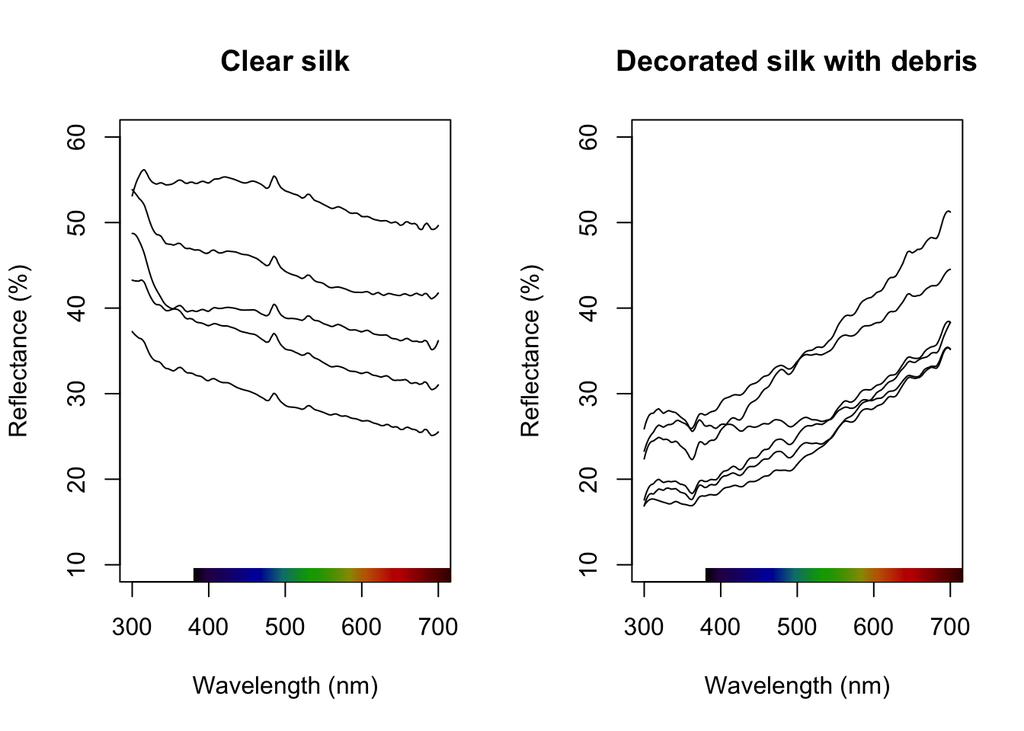

```r
par(mfrow=c(1, 2))
plot(c.specs, ylim = c(10, 60), main = "Clear silk")
plot(d.specs, ylim = c(10, 60), main = "Decorated silk with debris")
```

### Aggregated spectra plot

This allows to visualise the average reflectance spectra per silk retreat type

```r
decorated.B <- sub(".*_", "", colnames(d.specs)[-1])
clear.B <- sub("_.*", "", colnames(c.specs)[-1])
groups <- c(clear.B, decorated.B)

both <- merge(c.specs, d.specs)
names(both)
```

```
##  [1] "wl"                 "Sample_01"          "Sample_02"
##  [4] "Sample_03"          "Sample_04"          "Sample_05"
##  [7] "1068_03_03_blankie" "1106_05_02_blankie" "1116_05_02_blankie"
## [10] "1116_05_13_blankie" "1118_05_05_blankie" "1120_05_01_blankie"
```

### Spectra curves

Visualizing the mean reflectance curves for each sample type using Tidyverse

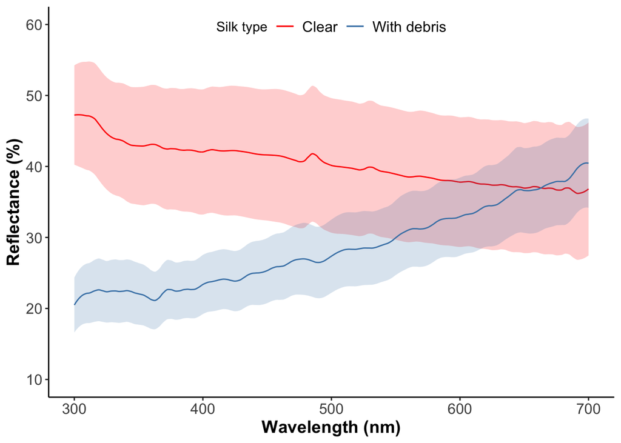

```r
colour_spec_type <- c("clear" = "red", "debri" = "steelblue")

both %>%
  rowwise(wl) %>%
  mutate(mean_clear = mean(c_across(contains("Sample"))),
         sdv_clear = sd(c_across(contains("Sample")))) %>%
  mutate(mean_debri = mean(c_across(contains("blankie"))),
         sdv_debri = sd(c_across(contains("blankie")))) %>%
  ggplot(aes(x = wl)) +
  geom_ribbon(aes(ymin = mean_clear-sdv_clear, ymax = mean_clear+sdv_clear),
              fill = "red",
              alpha = 0.2) +
  geom_line(aes(y = mean_clear, colour = "clear")) +
  geom_ribbon(aes(ymin = mean_debri-sdv_debri, ymax = mean_debri+sdv_debri),
              fill = "steelblue",
              alpha = 0.2) +
  geom_line(aes(y = mean_debri, colour = "debri")) +
  expand_limits(y = c(10, 60)) +
  scale_y_continuous(n.breaks = 10) +
  labs(x = "Wavelength (nm)", y = "Reflectance (%)") +
  scale_colour_manual(name="Silk type", values = colour_spec_type,
                      labels = c("Clear", "With debris")) +
  theme_poncho()  +
  theme(legend.position=c(0.5, 0.95), legend.direction = "horizontal")
```

```r
# ggsave(filename = "clear_vs_debris.pdf", device = "pdf", path = "./Output", width = 7, height = 5)
```